# CS 422 Section 01

Saptarshi Chatterjee (cwid - 20413922)

## 2.1 Decision tree classification

#### Part 2.1 Decision tree classification

```r
#Load libraries
library(rpart)
library(caret)
library(rpart.plot)
library(ROCR)
options("digits"=3)
rm(list=ls())
```

```r
# Load the Diabetes dataset and set seed
setwd("~/Desktop/Assignments&Coursework/422/Hw-2-March4/")
set.seed(1122)
adult.train <- read.csv("adult-train.csv", header=T, sep=",")
adult.test <- read.csv("adult-test.csv", header=T, sep=",")
dim(adult.train)
dim(adult.test)
```

[output not shown]

#### 2.1(a) Remove all the observations that have ‘?’ in them. Do the same thing for the test dataset.

```r
delete.dirt <- function(DF, dart=c('?')) {
  dirty_rows <- apply(DF, 1, function(r) !any(r %in% dart))
  DF <- DF[dirty_rows, ]
}
adult.train <- delete.dirt(adult.train)
adult.test <- delete.dirt(adult.test)
dim(adult.train)
```

```
[1] 30161    15
```

```r
dim(adult.test)
```

```
[1] 15060    15
```

#### 2.1(b) Build a decision tree model using rpart() to predict whether a person makes <=50K or >50K using all of the predictors.(b) (i) Name the top three important predictors in the model? (b).(ii) The first split is done on which predictor? What is the predicted class of the first node? What is the distribution of observations between the “<=50K” and “>50K” classes at this node?

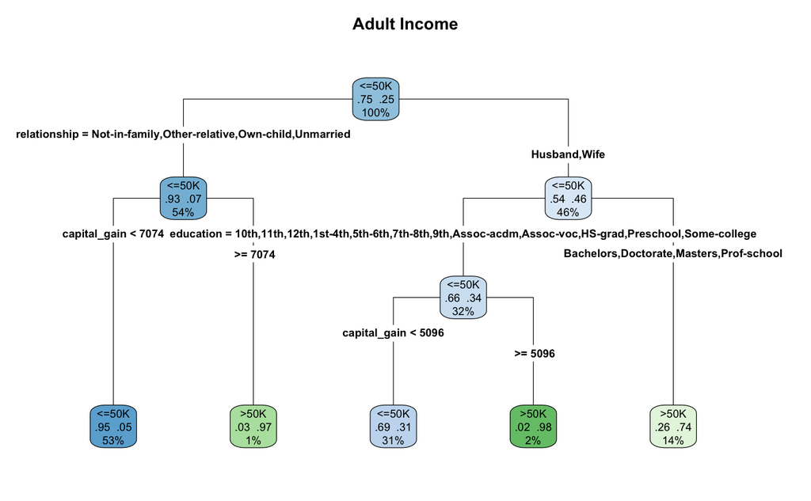

```r
adult.model <- rpart(income ~ ., method="class", data=adult.train)
rpart.plot(adult.model, extra=104, type=4, main="Adult Income")
```

```r
adult.model$variable.importance[1:3]
```

```
  relationship marital_status   capital_gain
          2277           2242            973
```

```r
sprintf("The first split is done on predictor -> %s", rownames(adult.model$splits)[1])
```

```
[1] "The first split is done on predictor -> relationship"
```

```r
sprintf("Predicted class of 1st Node -> %s", "<=50K")
```

```
[1] "Predicted class of 1st Node -> <=50K"
```

```r
sprintf("distribution of the <=50K and >50K at RootNode -> .7511 , .2489")
```

```
[1] "distribution of the <=50K and >50K at RootNode -> .7511 , .2489"
```

#### 2.1(c) Use the trained model from (b) to predict the test dataset. Answer the following questions based on the outcome of the prediction and examination of the confusion matrix:

```r
adult.pred <- predict(adult.model, adult.test, type="class")
cMat <- confusionMatrix(adult.pred, adult.test[,15])
cMat
```

```
Confusion Matrix and Statistics

          Reference
Prediction <=50K  >50K
     <=50K 10772  1837
     >50K    588  1863

               Accuracy : 0.839
                 95% CI : (0.833, 0.845)
    No Information Rate : 0.754
    P-Value [Acc > NIR] : <2e-16

                  Kappa : 0.51
 Mcnemar's Test P-Value : <2e-16

            Sensitivity : 0.948
            Specificity : 0.504
         Pos Pred Value : 0.854
         Neg Pred Value : 0.760
             Prevalence : 0.754
         Detection Rate : 0.715
   Detection Prevalence : 0.837
      Balanced Accuracy : 0.726

       'Positive' Class : <=50K
```

#### 2.1(c).(i) What is the balanced accuracy of the model? (ii) What is the balanced error rate of the model? (c)(iii) What is the sensitivity? Specificity? (c)(iv) What is the AUC of the ROC curve. Plot the ROC curve

```r
print.AESeSp <- function(DF) {
  cat(sprintf("Balanced accuracy of the model -> %.3f\n", DF$byClass[11]))
  cat(sprintf("Balanced Error of the model -> %.3f\n", 1 - DF$byClass[11]))
  cat(sprintf("Specificity of the model -> %.3f\n", DF$byClass[2]))
  cat(sprintf("Sensitivity of the model -> %.3f\n", DF$byClass[1]))
}
print.AESeSp(cMat);
```

```
Balanced accuracy of the model -> 0.726
Balanced Error of the model -> 0.274
Specificity of the model -> 0.504
Sensitivity of the model -> 0.948
```

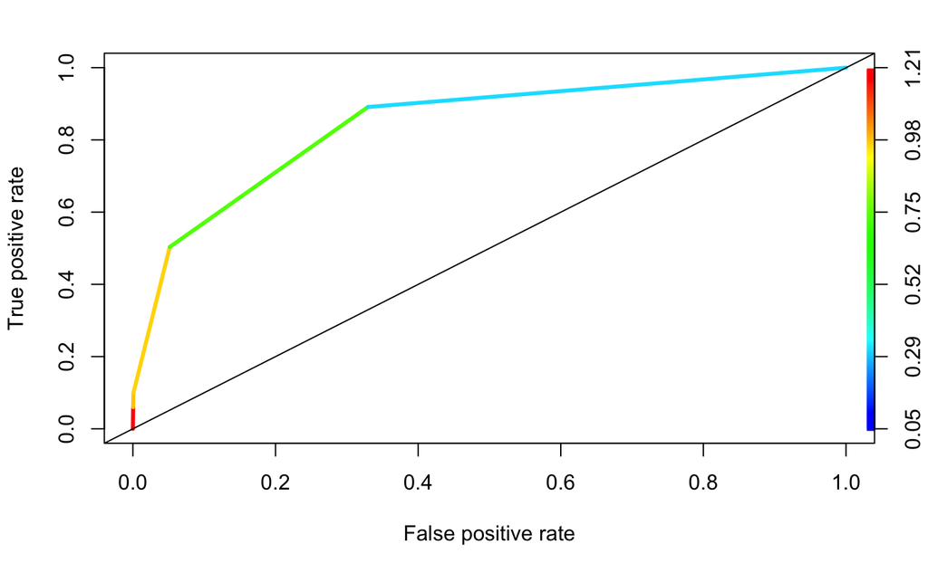

```r
pred.rocr <- predict(adult.model, newdata=adult.test, type="prob")[,2]
f.pred <- prediction(pred.rocr, adult.test$income)
f.perf <- performance(f.pred, "tpr", "fpr")
plot(f.perf, colorize=T, lwd=3)
abline(0,1)
```

```r
auc <- performance(f.pred, measure = "auc")
cat(paste("The area under curve (AUC) for this model is ", round(auc@y.values[[1]], 3)))
```

```
The area under curve (AUC) for this model is  0.843
```

#### 2.1 (d) Print the complexity table of the model you trained. Examine the complexity table and state whether the tree would benefit from a pruning. If the tree would benefit from a pruning, at what complexity level would you prune it? If the tree would not benefit from a pruning, provide reason why you think this is the case.

```r
printcp(adult.model)
```

```
Classification tree:
rpart(formula = income ~ ., data = adult.train, method = "class")

Variables actually used in tree construction:
[1] capital_gain education    relationship

Root node error: 7508/30161 = 0.2

n= 30161

    CP nsplit rel error xerror  xstd
1 0.13      0       1.0    1.0 0.010
2 0.06      2       0.7    0.7 0.009
3 0.04      3       0.7    0.7 0.009
4 0.01      4       0.6    0.6 0.008
```

```r
adult.model$cptable[which.min(adult.model$cptable[,"xerror"]), ]
```

```
       CP    nsplit rel error    xerror      xstd
  0.01000   4.00000   0.63852   0.63852   0.00846
```

Lowest “xerror” is associated with last level , so pruning the tree wont improve the model accuracy.

#### 2.1(e) There is a class imbalance problem in the training dataset. we will undersample the majority class such that both classes have the same number of observations in the training dataset.

#### 2.1(e)(i) In the training dataset, how many observations are in the class “<=50K”? How many are in the class “>50K”?

```r
sprintf("Number of observations are in the class <=50K are %d", sum(adult.train$income == "<=50K"))
```

```
[1] "Number of observations are in the class <=50K are 22653"
```

```r
sprintf("Number of observations are in the class >50K are %d", sum(adult.train$income == ">50K"))
```

```
[1] "Number of observations are in the class >50K are 7508"
```

#### 2.1(e)(ii) Create a new training dataset that has equal representation of both classes

```r
GR50K_ind <- which(adult.train$income == ">50K")
LE50K_ind <- which(adult.train$income == "<=50K")
nsamp <- length(GR50K_ind)
pick_GR50K_ind <- sample(GR50K_ind, nsamp)
pick_LE50K_ind <- sample(LE50K_ind, nsamp)
newTrainingDataset <- adult.train[c(pick_GR50K_ind, pick_LE50K_ind), ]
sprintf("Number of observations are in the class <=50K are %d", sum(newTrainingDataset$income == "<=50K"))
```

```
[1] "Number of observations are in the class <=50K are 7508"
```

```r
sprintf("Number of observations are in the class >50K are %d", sum(newTrainingDataset$income == ">50K"))
```

```
[1] "Number of observations are in the class >50K are 7508"
```

#### 2.1(e)Train a new model on the new training dataset, and then fit this model to the testing dataset. i) What is the balanced accuracy of this model? (ii) What is the balanced error rate of this model? (iii) What is the sensitivity? Specificity? (iv) What is the AUC of the ROC curve. Plot the ROC curve.

```r
balanced.model <- rpart(income ~ ., method="class", data=newTrainingDataset)
balanced.pred <- predict(balanced.model, adult.test, type="class")
balancedCM <- confusionMatrix(balanced.pred, adult.test[,15])
print.AESeSp(balancedCM)
```

```
Balanced accuracy of the model -> 0.803
Balanced Error of the model -> 0.197
Specificity of the model -> 0.835
Sensitivity of the model -> 0.771
```

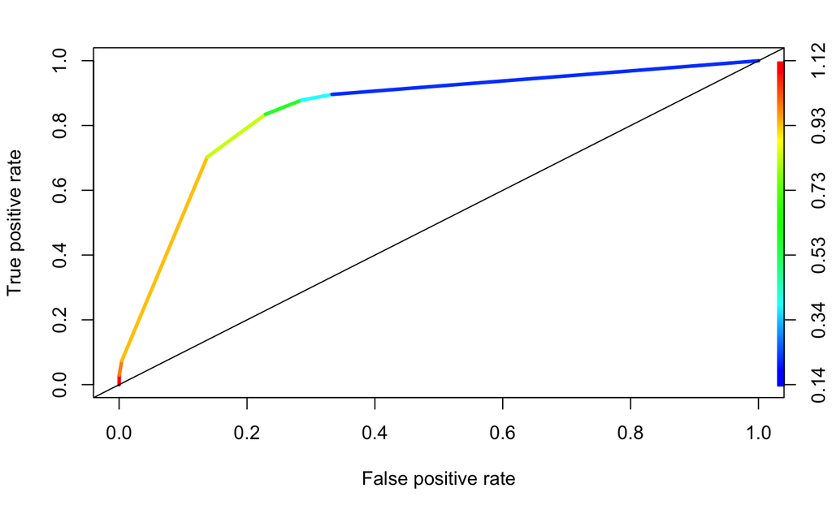

```r
pred.rocr <- predict(balanced.model, newdata=adult.test, type="prob")[,2]
f.pred <- prediction(pred.rocr, adult.test$income)
f.perf <- performance(f.pred, "tpr", "fpr")
plot(f.perf, colorize=T, lwd=3)
abline(0,1)
```

```r
auc <- performance(f.pred, measure = "auc")
cat(paste("The area under curve (AUC) for this model is ", round(auc@y.values[[1]], 3)))
```

```
The area under curve (AUC) for this model is  0.845
```

## 2.2 Random Forest

```r
library(randomForest)
```

#### 2.1.(a) Create a RF model using the entire training dataset. Once you have created the model, use the testing dataset to predict the response class. Execute the confusionMatrix() method on the predictions versus the true class response.

```r
forest.model <- randomForest(income ~ ., data = adult.train, importance=T)
forest.pred <- predict(forest.model, adult.test, type="class")
forestCM <- confusionMatrix(forest.pred, adult.test$income)
print(forestCM)
```

```
Confusion Matrix and Statistics

          Reference
Prediction <=50K  >50K
     <=50K 11325  2705
     >50K     35   995

               Accuracy : 0.818
                 95% CI : (0.812, 0.824)
    No Information Rate : 0.754
    P-Value [Acc > NIR] : <2e-16

                  Kappa : 0.351
 Mcnemar's Test P-Value : <2e-16

            Sensitivity : 0.997
            Specificity : 0.269
         Pos Pred Value : 0.807
         Neg Pred Value : 0.966
             Prevalence : 0.754
         Detection Rate : 0.752
   Detection Prevalence : 0.932
      Balanced Accuracy : 0.633

       'Positive' Class : <=50K
```

```r
print.AESeSp(forestCM)
```

```
Balanced accuracy of the model -> 0.633
Balanced Error of the model -> 0.367
Specificity of the model -> 0.269
Sensitivity of the model -> 0.997
```

```r
options("digits"=3)
sprintf("Accuracy of the model %f",forestCM$overall["Accuracy"])
```

```
[1] "Accuracy of the model 0.818061"
```

```r
sprintf("Total observations labelled as <=50K are %s",sum(forestCM$table[1,]))
```

```
[1] "Total observations labelled as <=50K are 14030"
```

```r
sprintf("Total observations labelled as >50K are %s",sum(forestCM$table[2,]))
```

```
[1] "Total observations labelled as >50K are 1030"
```

```r
sprintf("Ans to (v) Given the response class distribution this makes sense. As there is a data imbalance , Random forest does increase sensitivity of the model at the cost of Specificity")
```

```
[1] "Ans to (v) Given the response class distribution this makes sense. As there is a data imbalance , Random forest does increase sensitivity of the model at the cost of Specificity"
```

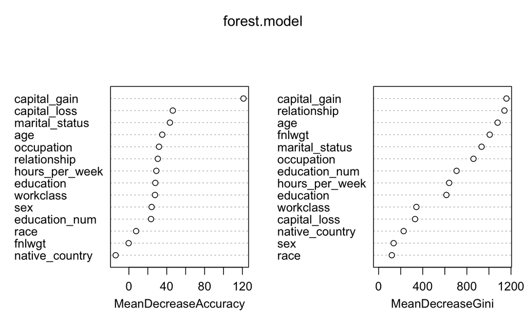

```r
varImp <- varImpPlot(forest.model)
```

```r
sprintf("Ans to (vi) MeanDecreaseAccuracy - Most Important 'capital_gain', least Important 'native_country' . MeanDecreaseGini - most important 'capital_gain', least important 'race'" )
```

```
[1] "Ans to (vi) MeanDecreaseAccuracy - Most Important 'capital_gain', least Important 'native_country' . MeanDecreaseGini - most important 'capital_gain', least important 'race'"
```

```r
print(forest.model)
```

```
Call:
 randomForest(formula = income ~ ., data = adult.train, importance = T)
               Type of random forest: classification
                     Number of trees: 500
No. of variables tried at each split: 3

        OOB estimate of  error rate: 18.2%
Confusion matrix:
      <=50K >50K class.error
<=50K 22595   58     0.00256
>50K   5422 2086     0.72216
```

```r
sprintf("(vii) What is the number of variables tried at each split -> %s", 3 )
```

```
[1] "(vii) What is the number of variables tried at each split -> 3"
```